# metasim package

Charles T. Gray

2019-05-04

# vignette text

## preamble

```r
library(metasim)
library(tidyverse)


# for reproducibility
set.seed(38)
```

## introduction

`metasim::` rather ambitiously attempts to lower the programmatic barrier to running simulation experiments for meta-analysts. The intended audience of this package are practicing scientists who wish to experiment to see how their chosen estimator works but who are not necessarily computational mathematicians.

Frequently, scientists wish to verify their results, and, in particular, that the broad findings hold for their particular context. For example, perhaps an estimator works well for some sample sizes and not others?

In the first application of the `metasim::` package meta-analysis of medians, the goal is to reduce the amount of code for reproducibility and accessibility. Given a comparison was required, there is a high risk of repetative code. And this, too, creates a barrier for scientists whose primary discipline is not programming. The more lines of repeated code, the more likely a small mistake will cause the entire analysis algorithm to grind to a halt. This is not insurmountable, but it *is* time consuming. Frequently the code was functional at the time of publication, but in the meantime the author has made some small change in the code and it no longer runs without debugging. This package aims to assist in smoothing the inevitable debugging process that accompanies the simulation of meta-analysis data.

### opinionated bit

Consider - three starting papers (Bland 2014; Hozo, Djulbegovic, and Hozo 2005; Wan et al. 2014) + example dataset (Barros Pinheiro et al. 2012) of motivating problem, these were not written by statisticians. Thus, it’s okay for software to be opionated. And indeed, we must, as methodologists, make necessary choices about presentation and implementation that carry the value judgement of opinion. There are often multiple ways to solve a problem, and it is not always helpful to provide all possible solutions. Often the end-user wishes to find a useful guide.

## the package in a glance

An advantage with standardised results, whatever they may be

## some maths

## some maths

## applications

### meta-analysis of medians

The `metasim::` package began as a script to solve this particular problem, and so it is currently the default simulation parameter set for `metasims()`.

#### the problem

#### simulation parameters

In order to compare the performance of the estimator, we wished to consider a number of different contraints.

```r
metasims_args <- args(metasims) %>% as.list()
metasims_args %>% names()
```

```
##  [1] "single_study"   "measure"        "measure_spread" "distributions"
##  [5] "k"              "tau2_true"      "effect_ratio"   "min_n"
##  [9] "max_n"          "prop"           "prop_error"     "trials"
## [13] "trial_fn"       "beep"           "progress"       ""
```

There is scope to extend the number of distributions in future releases of `metasim::`. Furthermore, the question of the best selection of parameter remains for future work. For example, incorporating elements from experimental design (Steponavič? et al. 2016) into the construction of the simulation parameter set.

A set of default parameters is exported as a data object `default_parameters` in `metasim::`.

```r
default_parameters %>% knitr::kable()
```

| dist | par |
| --- | --- |
| norm | list(mean = 2, sd = 0.3) |
| exp | list(rate = 2) |
| pareto | list(shape = 3, scale = 3) |
| pareto | list(shape = 2, scale = 1) |
| pareto | list(shape = 0.5, scale = 1) |
| lnorm | list(meanlog = 1, sdlog = 0.3) |

#### default distributions

[figure not shown]

#### ratio plots

#### single-study simulation

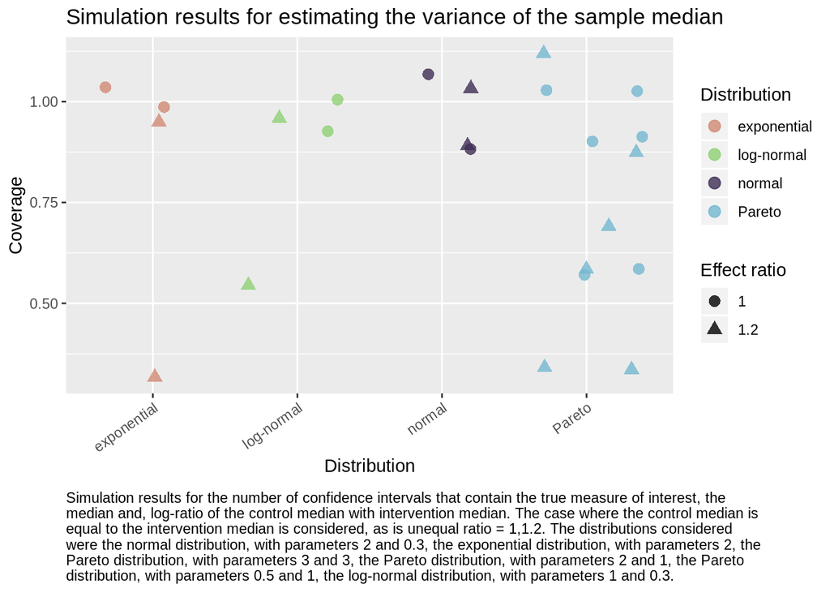

#### meta-analysis simulation

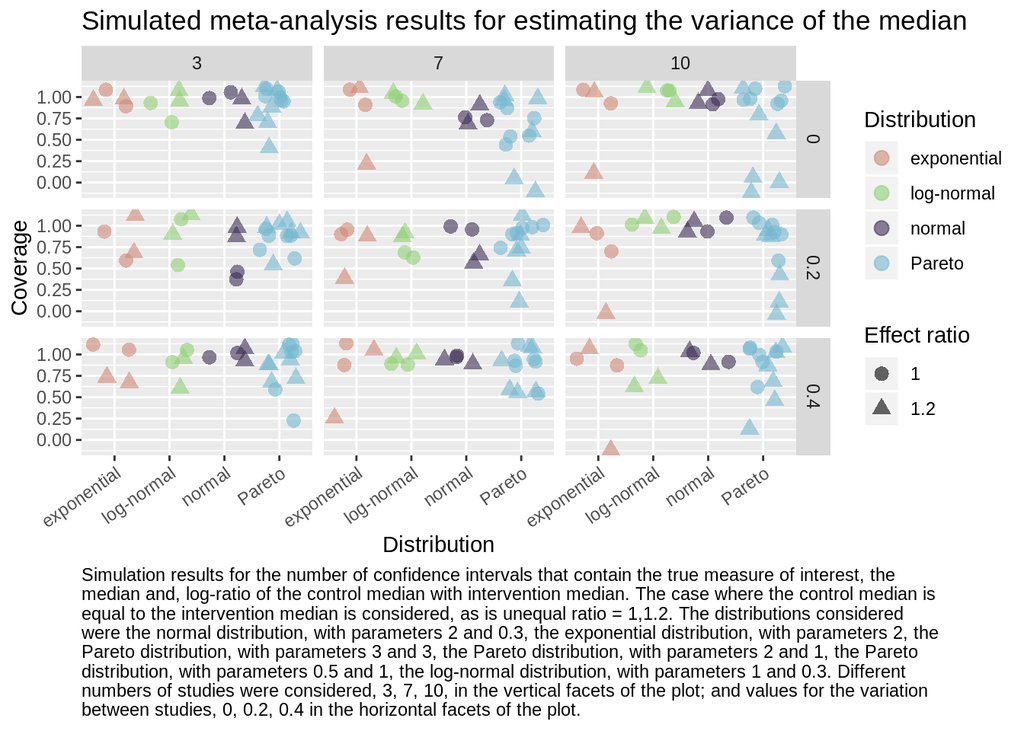

## references

Barros Pinheiro, Melina de, Daniela Rezende Garcia Junqueira, Fernanda Fonseca Coelho, Let’ıcia G. Freitas, Maria G. Carvalho, Karina Braga Gomes, and Luci Maria Santana Dusse. 2012. “D-Dimer in Preeclampsia: Systematic Review and Meta-Analysis.” *Clinica Chimica Acta; International Journal of Clinical Chemistry* 414 (December): 166–70. https://doi.org/10.1016/j.cca.2012.08.003.

Bland, Martin. 2014. “Estimating Mean and Standard Deviation from the Sample Size, Three Quartiles, Minimum, and Maximum.” *International Journal of Statistics in Medical Research* 4 (1): 57–64–64. http://lifescienceglobal.com/pms/index.php/ijsmr/article/view/2688.

Hozo, Stela Pudar, Benjamin Djulbegovic, and Iztok Hozo. 2005. “Estimating the Mean and Variance from the Median, Range, and the Size of a Sample.” *BMC Medical Research Methodology* 5 (1): 13. https://doi.org/10.1186/1471-2288-5-13.

Parker, Hilary. 2017. “Opinionated Analysis Development.” *Preprint*. https://doi.org/10.7287/peerj.preprints.3210v1.

Steponavič?, Ingrida, Mojdeh Shirazi-Manesh, Rob J. Hyndman, Kate Smith-Miles, and Laura Villanova. 2016. “On Sampling Methods for Costly Multi-Objective Black-Box Optimization.” In *Advances in Stochastic and Deterministic Global Optimization*, edited by Panos M. Pardalos, Anatoly Zhigljavsky, and Julius Žilinskas, 107:273–96. Cham: Springer International Publishing. https://doi.org/10.1007/978-3-319-29975-4_15.

Wan, Xiang, Wenqian Wang, Jiming Liu, and Tiejun Tong. 2014. “Estimating the Sample Mean and Standard Deviation from the Sample Size, Median, Range and/or Interquartile Range.” *BMC Medical Research Methodology* 14 (1): 135. https://doi.org/10.1186/1471-2288-14-135.